# Love, the heart of Songs’ Spirituality

Xudong Guo

September 17, 2019

## Overview

Always motivated and inspired by different types of songs, I am fanatical about the subconscious part of the author’s mind when a song lyric was generated. This project renders me great opportunity in exploring intuitive logics between words and sentences by using text mining as well as natural language processing methods.

## Introduction

The processed_lyrics dataset was provided by Professor and modified from the original one so that important and meaningful words were stemmed from the song lyrics. We have 125704 rows and 7 columns which including variables “song”, “year”, “artist”, “genre”, “lyrics”, “id” and “stemmedwords”. The years of songs ranging from 112 to 2016 and genres classified into 12 categories: “Country”, “Electronic”, “Folk”, “Hip-Hop”, “Indie”, “Jazz”, “Metal”, “Pop”, “R&B”, “Rock”, “Other” and “Not Available” which are the two major variables I will mainly focus on besides variable “stemmedwords”.

## The Analysis of Song Lyrics

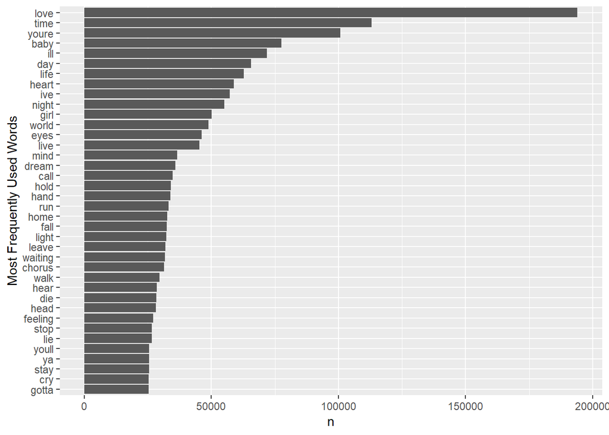

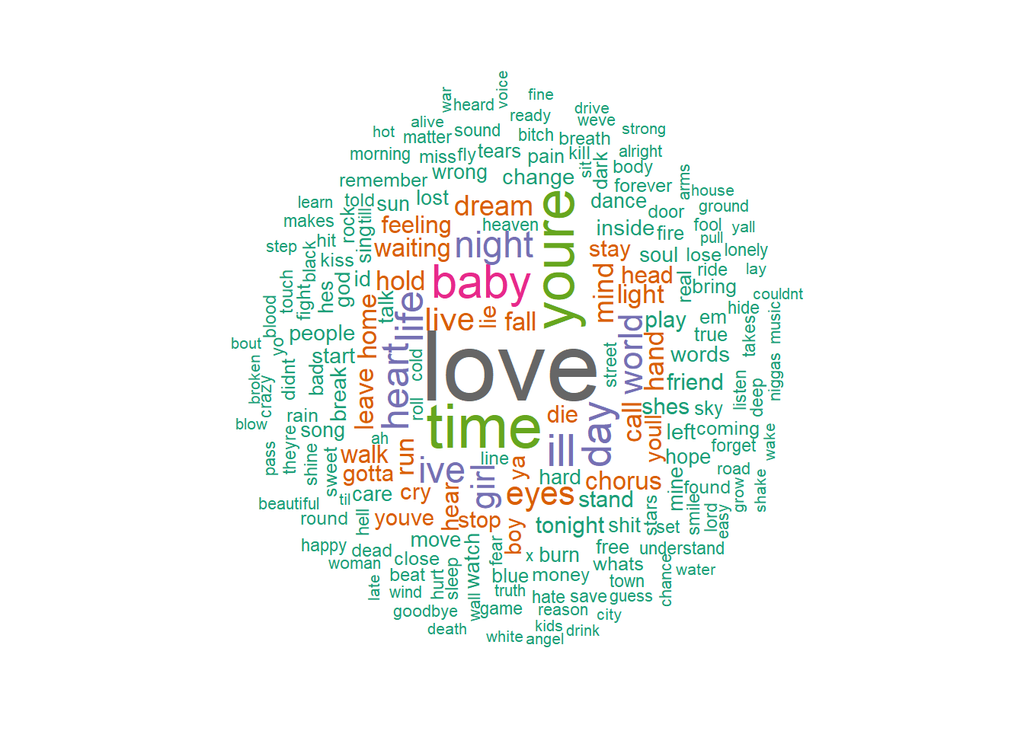

When taking all the song lyrics as a whole and looking at each individual words, not surprisingly, the word “love” appears most frequently then follows with “time”, “youre” and “baby”. The word “ill” appears 71915 times which far exceeds my expectation.

### The Sentiment Analysis

| genre | word | n | freq |
| --- | --- | --- | --- |
| Pop | love | 53150 | 2.8427020 |
| R&B | love | 6055 | 2.7851886 |
| Jazz | love | 9409 | 2.2826298 |
| Not Available | love | 6843 | 2.0580451 |
| R&B | baby | 4128 | 1.8988040 |
| Other | love | 268 | 1.8231293 |
| Country | love | 13308 | 1.7663924 |
| Electronic | love | 4865 | 1.7300853 |
| Hip-Hop | love | 15234 | 1.7107243 |
| Other | baby | 212 | 1.4421769 |

[output cut: 10 more lines]

By referring to the nrc lexicon, I am mostly interested in the negative emotion: anger as well as the positive emotion: joy. When grouping by genre, words representing joy such like “love” and “baby” have significant appearances. For the word “love”, Pop, R&B and Jazz music dominate the top three ranking in terms of frequency, that is, the number of “love” appearances over all word counts in each genre. On the other hand, Hip-Hop music has the highest frequency of negative words like “shit”, “ill” which are representing anger.

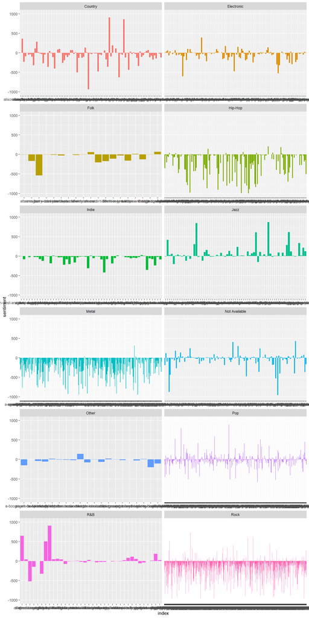

From the sentiment analysis plots which categorized by lyrics genre and due to the frequency calculation in previous parts, it’s not counterintuitive that Hip-Hop always delivers negative emotions as well as Indie, Metal and Folk. On the contrary, most Jazz lyrics are full of positive emotions such as love and happiness.

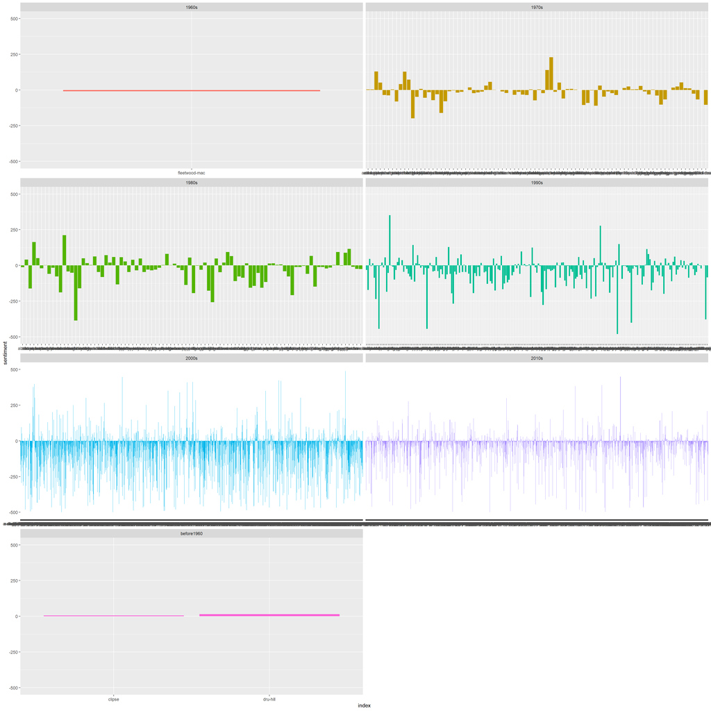

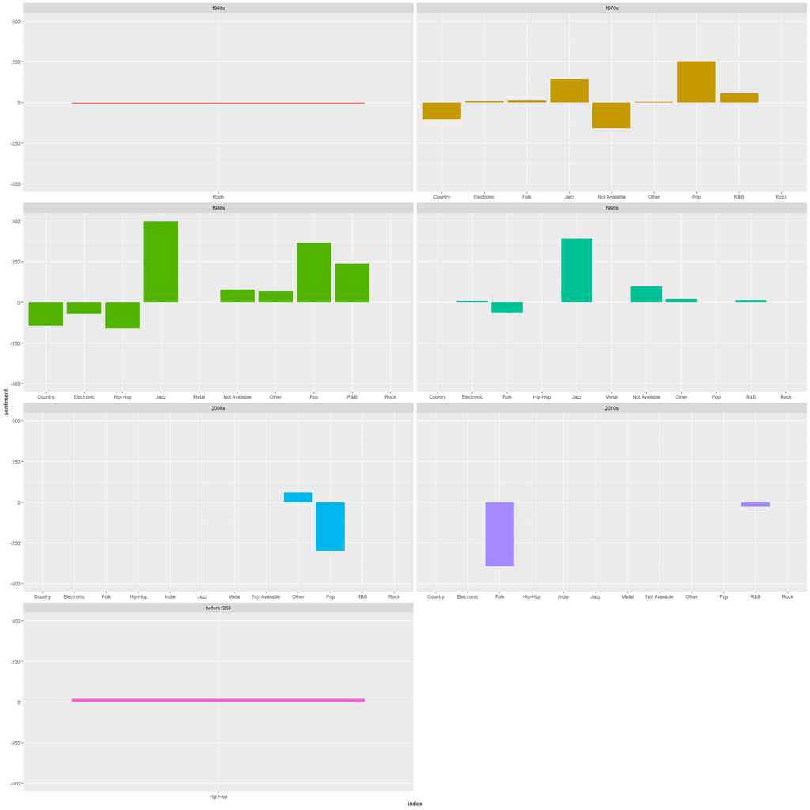

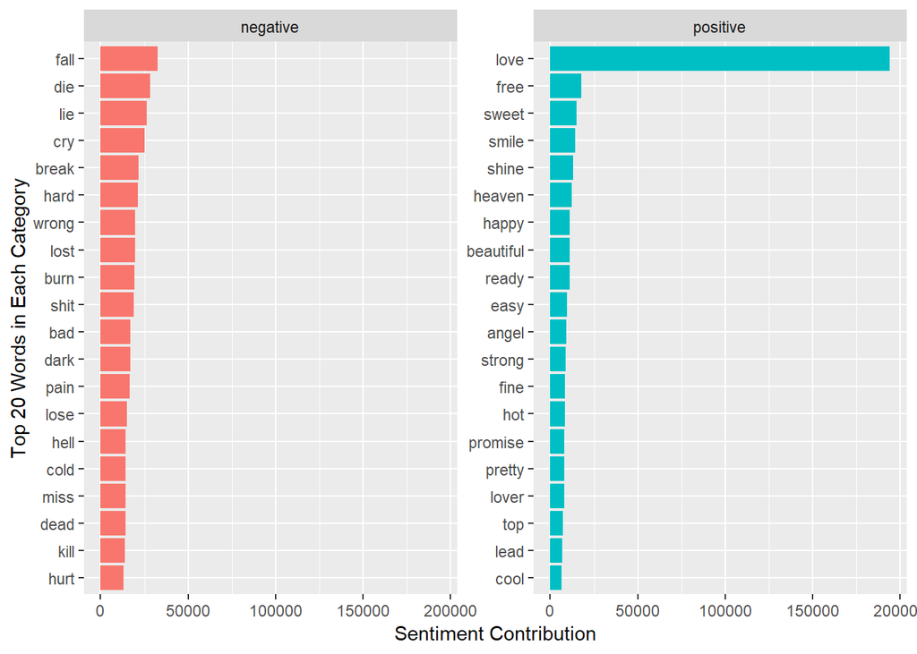

So besides the word “love”, what other vocabs those artists use to deliver their either bad or good emotions? For the positive emotion, “free”, “sweet”, “smile”, “shine” are frequently used.For the negative emotion, “fall”, “die”, “lie” and “cry” are commonly applied.

### Bigrams Analysis

| wordone | wordtwo | n |
| --- | --- | --- |
| love | baby | 4463 |
| baby | love | 4123 |
| close | eyes | 4077 |
| fall | love | 3828 |
| live | life | 3378 |
| rock | roll | 2934 |
| set | free | 2875 |
| break | heart | 2737 |
| chorus | x | 2729 |
| love | youre | 2650 |

When using two-grams approach, the most likely combination is “love baby” then follows with “baby love”, “close eyes” and “fall love” which mostly in positive emotions. Unlike positive attitudes are often expressed in two words, negative emotions are delivered in a single word.

| wordone | wordtwo | n |
| --- | --- | --- |
| love | baby | 4463 |
| baby | love | 4123 |
| fall | love | 3828 |
| love | youre | 2650 |
| true | love | 2346 |
| love | time | 2335 |
| ill | love | 2308 |
| youre | love | 2169 |
| time | love | 2123 |
| love | ill | 2085 |

Although there are a bunch of negative emotions in the song lyrics right now, love is still deeply rooted in people’s mind. Subconsciously, no one would deny the strength of love and we use love to reveal their true needs. The table above shows the most frequently combinations with at least a word “love”. Words such like “time”, “baby”, “true” are with “love” quite often.

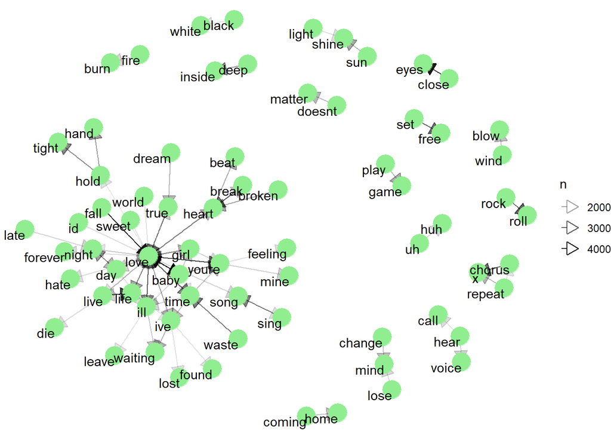

Based on the bigrams visualization, “love” is always the heart of lyrics which connecting with “sweet”, “forever”, “life”, “day”, etc. In additions, some combinations are also popular such like “light shine”, “heart broken”, “doesn’t matter”, “wind blow”, etc.

## Conclusions

La Vie en Rose, my most favorite jazz song, is always inspirational. Unsurprisingly, based on the sentimental analysis, jazz music is the genre which lyrics are most likely delivering positive emotions. There is a strong pattern that more and more negative emotions are involved into song lyrics. Meanwhile, people’s taste has changed from Jazz, R&B to Pop and Folk music. “Love” is the most frequently used word in song lyrics which always combined with “sweet”, “forever”, “baby”, “heart”, etc. On the other hand, “fall” and “die” are the most frequently used words with negative emotions.